# Worksheet: Project 1

# Texas Spending, Environmental Violations, and Health Statistics

#### By: Gerardo Gonzalez, Erick Garcia, and Nicholas Calzada

## 1. Introduction

### Dataset 1: Texas Health Rankings

The first data set was provided by the County Health Rankings & Roadmaps (CHR&R) program by University of Wisconsin Population Health Institute. The dataset was retrieved from https://www.countyhealthrankings.org/explore-health-rankings/texas/data-and-resources and covers various different health statistics, ranging from death and mortality (of both adults and infants), high school graduates, drinking accidents, etc.

The dataset contains 256 rows, where the first 2 rows are the column names and each other row in this dataset representing info about a particular county in Texas. In this dataset, there are 162 columns. Since the dataset originated from a Microsoft Excel sheet and was later converted to a CSV file, certain columns were merged and then un-merged without a proper name. Excluding these columns with missing names, there are 82 columns, which give a statistic to each County based on

- Commute (Long commute - driving alone, …),
- Housing (Driving alone to work, …),
- Environmental Violations (Drinking water violations, Air pollution - particulate matter, …),
- Crime, death, and injuries (Violent crime, Injury deaths, …),
- and other Health Factors (Physical inactivity, Poor or fair health, Excessive drinking,…).

What intrigued us about this data set was the possibility of health disparities between counties in Texas, and to see if perhaps wealthier counties had better health statuses than less-wealthy counties.

### Dataset 2: Texas Commission on Environmental Quality

Our second dataset was provided by the Texas Commission on Environmental Quality. The dataset was retrieved from https://data.texas.gov/dataset/Texas-Commission-on-Environmental-Quality-Notices-/mwzi-gyw7 and covers investigations leading to a Notice of Violation (NOV).

The dataset contains 1.2 million rows, as it covers data from each county from 2011 to 2023. Each row in this dataset represents a Notice of Violation. In this dataset, there are 25 columns, correlating to

- Identification (Customer Name, Investigation Number, Notice of Violation Date, …),
- Location data (Mailing Address, County, Latitude, Longitude…),
- and Violation Classification (Rule Citation, Media, Violation Category…).

What is particularly interesting about this dataset is while it does contain a plethora of environmental violations, there does not appear to be a grand number of classifications. For example, all of the information on NOVs seem to fall under only 3 media: Water, Air, and Waste. Similarly, NOVs fall under only 3 Violation Categories: A, B, and C.

### Dataset 3 : Texas State Expenditures

Our third dataset was provided by the Texas Comptroller of Public Accounts. The dataset was retrieved from https://data.texas.gov/Government-and-Taxes/Texas-State-Expenditures-by-County-2018/f2iw-dtqt and documents the amounts of money allocated by the state of Texas to each county, as well as the corresponding expenditure category.

The dataset contains 88,707 rows, with each row representing a distinct expenditure made. The dataset contains 6 different variables, which are both

- Numerical (Fiscal Year, Agency Number, and Amount),
- and Categorical (Agency Name, County, and Major Spending Category).

What intrigued us about this data set was to see the relationship between the amount and category of money allocated. Furthermore, when investigating the top-ranked average salary group, we wondered if the counties represented would be well-known, larger counties.

## 2. Data Exploration

### Libraries and Importing Datasets

```r
library(tidyverse)
library(readr)
TX_Envm <- read_csv("Texas_Commission_on_Environmental_Quality_-_Notices_Of_Violation__NOV_.csv")
TX_Exp <- read_csv("Texas_State_Expenditures_by_County_-_2018.csv")
TX_Health <- read_csv("2017 County Health Rankings Texas Data - v2.csv")
```

- Due to Excel, merged cells that were unmerged have no names: `…1`, `…2`, etc. Additionally, the 1st row is the names of what the columns should be.

```r
### Renaming the Column Names
for (i in (seq(1:length(TX_Health)))){
  colnames(TX_Health)[i] <- TX_Health[1,i]
}
```

- Next, Tidyverse functions do not work when there are columns with identical names
  - Specifically, all the columns that contain z-scores and confidence intervals. Since these columns wont be utilized in our analysis, we’d like to remove them.

```r
### Removing Repeated Columns
TX_Health <-
  TX_Health[, !duplicated(colnames(TX_Health))]

TX_Health <- TX_Health %>%
  select(-"95% CI - Low", -"95% CI - High", -"Z-Score")
```

- Lastly, the first row is just a repeat of the column names, so we just remove that row

```r
### Removing First Row
TX_Health <- TX_Health %>% slice(2:256)
```

Thus, we now have the dataset `TX_Health` that we will be using throughout the project.

### RQ 1: Air Violations and Air Pollution

The first research question, that will be explored, is the relationship between the amount of **air violations** in a given county (in the dataset `TX_Envm`) and the average daily “$pm_{2.5}$” (in the dataset `TX_Health`).

Knowing this, let’s create a joined dataset, `RQ_1`, for this research question utilizing both `TX_Envm` and `TX_Health`. However, we must keep some issues in mind:

**Cleaning Data:**

```r
## First Issue:
  TX_E<-TX_Envm # Convert dataset to a different name
  TX_E$County = str_to_sentence(TX_E$County) # Corrects the letter case for county column
  full_join(TX_Health, TX_E, by = "County") %>%  # Information from both datasets, join by county
## Second Issue:
  separate(`Notice of Violation Date`, # Separates the date into 3 columns
           into = c("Month", "Day", "Year"),  # Columns: month, day, and year
           sep = "/",
           convert = T) %>%
  filter(Year == '2017') %>% # Filters and leaves only data from 2017
## Third Issue:
  filter(!is.na(County)) %>% # Filters and removes all n/a values for county
## Fourth Issue:
  select(County, Media, "Violation Category","Average Daily PM2.5") %>% # Selects the columns
## Fifth Issue:
  rename(Pollution = 'Average Daily PM2.5' # Rename column into "Pollution"
          ) -> RQ_1 # Rename the new dataset to "RQ_1"
```

However, upon a quick glance at the dataset, one would notice many different variables without clear definitions. Therefore, a quick discussion about the semantics of key variables within our new dataset:

- $pm_{2.5}$: Withing the category `Pollution`, the unit $pm_{2.5}$ describes the fine inhalable particles, with a diameter that are 2.5 micrometers or smaller (hence the name). It should be noted, that the World Health Organization (WHO) sets a standard of $5 µg/m^3$ (daily average) and the Environmental Protection Agency (EPA) sets a standard of $12 µg/m^3$ (daily average). It is not our place to dictate which is correct, that distinction will be left for governmental agencies. However, it is a generally accepted that a larger number is associated with worse pollution, and will thus be interpreted in this manner.
- `Media`: The Texas Commission on Environmental Quality (TCEQ) separates violations into three distinct categories: Air, Waste, and Water. Each category contains a broad range of violations, but all pertain to the category in which they are under. In this portion of the study, we will be investigating violations under the category of `Air`.
- `Violation Category`: The Texas Commission on Environmental Quality (TCEQ) further separates violations based upon their Enforcement Initiation Criteria (EIC). This criteria assesses the severity of the violation and labels the violation either as A, B, or C:
  - A = A regulatory violation, it is the least severe and it typically manifests itself as a failure to report requirements (improper permits, failure to keep proper records, etc…)
  - B = A general violation, it is not serious by nature but poses occupational health hazards to employees.
  - C = A serious violation, it is the most severe and poses serious health risks to the general public as well as employees.

**Cleaning Data Continued:**

```r
## Further Cleaning...
RQ_1 <- RQ_1 %>%
  filter(Media == "AIR", # Removes all other violations apart from air
         !is.na(Pollution)) # Removes all n/a values for Pollution
RQ_1$Pollution <- as.numeric(RQ_1$Pollution) # Sets the values for "Pollution" as numeric
```

Now, after cleaning/tidying the data, we are left with 13,218 rows and four separate columns. Let us begin to look at the relationship between `air violations` and `Pollution`. First let us begin with `Pollution`. As described above, there are different levels of “safety” depending on the governing body. Let’s arrange the values of `Pollution` (Average Daily $pm_{2.5}$) to see which counties have the highest values.

```r
## List of counties based on their air pollution in descending order
RQ_1_desc <- RQ_1 %>%
  group_by(County) %>% # Groups the observations by county
  slice(1:1) %>% # Takes one observation for each county
  arrange(desc(Pollution)) # Arranges the counties based on pollution in a descending order
head(RQ_1_desc)
```

```
## # A tibble: 6 × 4
## # Groups:   County [6]
##   County     Media `Violation Category` Pollution
##   <chr>      <chr> <chr>                    <dbl>
## 1 Harris     AIR   B                         12
## 2 Montgomery AIR   B                         11.4
## 3 Brazoria   AIR   B                         11.2
## 4 Denton     AIR   B                         10.9
## 5 Tarrant    AIR   B                         10.9
## 6 Collin     AIR   B                         10.8
```

It can be observed that Harris county has the highest levels of Average Daily $pm_{2.5}$. The values are much higher than that of which the WHO recommends but still meets the EPA regulations (exactly the same amount).

Now with more insight, let’s create a univariate graph that displays the `Pollution` values of each of county to better grasp the data.

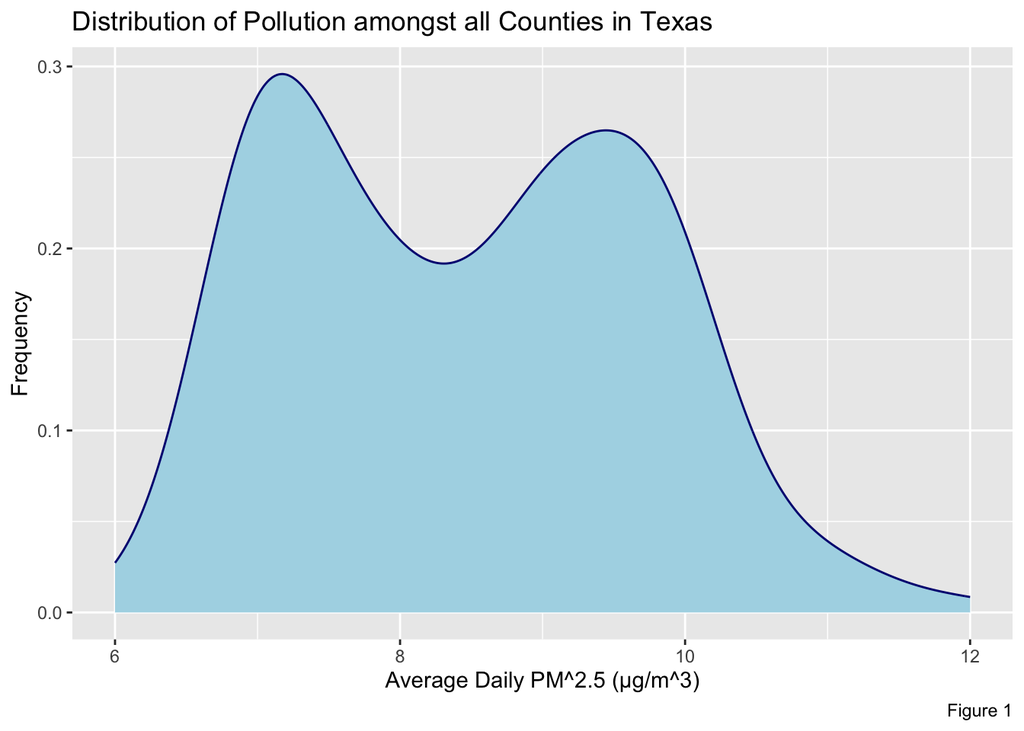

```r
## This function creates a univariate graph on pollution across all Texas counties
RQ_1 %>%
  group_by(County) %>% # Groups all variables by county
  slice(1:1) %>% # Takes one observation for each county
  select(Pollution) %>%   # Select only the pollution column

    ggplot(aes(Pollution)) + # ggplot function with pollution as the only variable
    geom_density(fill = "lightblue", color = "navy") +   # Specifies the density plot
  # Sets the title, caption, and x.y axis for the graph
    labs(title = "Distribution of Pollution amongst all Counties in Texas",
       caption = "Figure 1",
       x = bquote("Average Daily PM^2.5 (µg/m^3)"),
       y = "Frequency") +
  theme_gray() # Sets the theme for the graph
```

As one can observe, the majority of average daily $pm_{2.5}$ values lie between both of the agencies recommendations. However, the EPA dictates the law within the United States, therefore, it makes sense that not one county in Texas has a average daily $pm_{2.5}$ over their regulations.

Next, let us answer our research question: is there a relationship between number of air violations and air pollution in a county? Let us construct a bivariate visualization of the data.

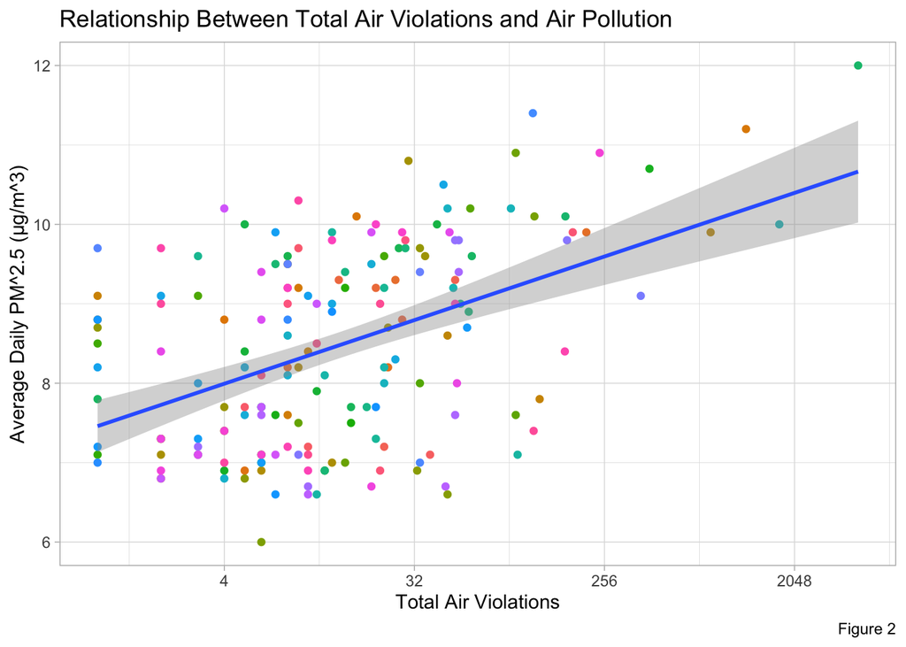

```r
## This function produces a bivariate graph of the total number of violations and respective air pollution for each county in Texas
RQ_1 %>%
  group_by(County) %>% # Groups all the data by county
  summarize(Total = n(), Pollution) %>%  # Count the total number of violations
  slice(1:1) %>% # Takes on observation of each county, with the new total variable

    ggplot(aes(x = Total, y = Pollution)) + # ggplot: total on the x-axis and pollution on the y-axis
    geom_point(aes(color=County)) +
    # Sets the title, caption, and x.y axis for the graph
    labs(title = "Relationship Between Total Air Violations and Air Pollution",
       caption = "Figure 2",
       x = "Total Air Violations",
       y = "Average Daily PM^2.5 (µg/m^3)") +
  theme_light() +  # Sets the theme for the graph
  theme(legend.position = "none") + # Removes the legend
  scale_x_continuous(trans = 'log2') + # Sets the x-axis in the log scale
  geom_smooth(method = lm) #line of best fit for the data in the graph
```

The resulting graph displays the total number of violations against the average daily $pm_{2.5}$ for each county, with $pm_{2.5}$ having the units of $µg/m^3$. In addition, each point on the graph represents a separate county and is positioned based on the aforementioned characteristics. With the addition of a best fit line, it is incredibly apparent that there is a positive correlation between the total number of violations and the average daily $pm_{2.5}$ within each county. It should be noted, however, that a decision was reached to set the x-axis at an exponential scale to properly suite the wide range of values. Nonetheless, this decision does not impact the conclusions made. In summary, **there is a positive relationship between air quality and total number of air violations within counties in Texas**.

### RQ 2: Salaries/Wages Per County and Respective Health

In order to begin the exploration into the relationship between the amount of money for salaries and wages allocated to each county and the percentage of fair or poor health status, the data sets had to be cleaned in order to be properly joined. The expenditures data set was first filtered to only include data from the year 2017, and then only the rows with a county name were selected. The data was then filtered again to focus on the salaries and wages category, and then the rows were grouped by county. A summarize function was then used to calculate the total wages and salaries, as well as the average salaries and wages, each in units of thousands of dollars. By grouping by county, the new data set only included one row per county, which was the intended goal.

```r
TX_2017_SalWage <- TX_Exp %>%
  filter(`Fiscal Year` == 2017) %>% # filtering expenditure data for only 2017
  filter(!is.na(County)) %>% # Removing rows with missing county name
  filter(`Major Spending Category` == 'SALARIES AND WAGES') %>%  # Choosing the spending category
  select(County, `Major Spending Category`, Amount) %>%
  group_by(County) %>% # Grouping the data based on the county name
  # Total and average salaries will be in units of 1000s of dollars
  summarize(Total_Sal_Wages = sum(Amount)/1000,
            Avg_Sal_Wages = mean(Amount)/1000)

nrow(TX_Exp)
```

```
## [1] 88707
```

```r
nrow(TX_2017_SalWage)
```

```
## [1] 253
```

Before filtering the data, the expenditures data had a total of 88,707 observations, whereas the cleaned data set had a total of 253 observations. Texas has a total of 254 counties, thus a more detailed look into the expenditures data set was performed in order to determine which county was being excluded.

```r
#finding any data that is not shared between the two data sets
missingCounty <- anti_join(TX_Exp, TX_2017_SalWage, by = 'County')

# filtering any NA county to reveal the actual missing county
actual_missingCounty <- missingCounty %>%
  filter(!is.na(County))
head(actual_missingCounty)
```

```
## # A tibble: 6 × 6
##   `Fiscal Year` `Agency Number` `Agency Name`              County Major…¹ Amount
##           <dbl>           <dbl> <chr>                      <chr>  <chr>    <dbl>
## 1          2017             212 OFFICE OF COURT ADMINISTR… LOVING INTERG…  5354.
## 2          2017             241 DISTRICT COURTS - COMPTRO… LOVING INTERG… 25249.
## 3          2017             302 OFFICE OF THE ATTORNEY GE… LOVING OTHER …    73
## 4          2017             304 COMPTROLLER OF PUBLIC ACC… LOVING OTHER …    48
## 5          2017             305 GENERAL LAND OFFICE        LOVING OTHER …   360
## 6          2017             307 SECRETARY OF STATE         LOVING PUBLIC…  -932.
## # … with abbreviated variable name ¹`Major Spending Category`
```

```r
# finding data associated with Loving county
lovingCounty <- TX_Exp %>%
  filter(`Fiscal Year` == 2017) %>%
  filter(County == 'LOVING') %>%
  select(County, `Major Spending Category`, Amount)
```

This examination revealed that Loving county was missing from the newly created data set. This is because no expenditures for the salaries and wages category were reported for Loving county in 2017, meaning the original filtering process excluded this county.

Next, the health data set was cleaned by removing rows with a missing county name, and by grouping the data by county as was done in the expenditures data set. The `% Fair/Poor` variable was then converted into a numeric variable, since it was originally classified as a character. The county names were then all capitalized in order to match the county name format in the expenditures data set, which would allow the two to be joined properly. The `County` variable was then used to join each data set, which resulted in a data set with 254 rows.

```r
TX_HealthClean <- TX_Health %>%
  # Removing missing county observations
  filter(!is.na(County)) %>%
  group_by(County) %>%
  # Mutating the character variable to now be a numeric variable
  mutate(`% Fair/Poor` = as.numeric(`% Fair/Poor`),
         # Capitalizing all county names in order to properly join with the other            # data set
        County = toupper(County)) %>%
  select(County, `% Fair/Poor`)

# joining both datasets by the ID of 'County'
joinedHealthAndSal<-full_join(TX_2017_SalWage, TX_HealthClean, by = 'County')
```

To begin this exploration, the counties with the top 10 highest average salary and wage allocation were selected and used to create a new data set named `topWages`. A scatter plot was then created, with the inclusion of an aesthetic argument to color each point based on the unique county it represented, where each point’s label is provided in the legend to the right. It was initially believed that a higher average salary and wage allotment would correspond to a lower percentage of fair or poor health status, while a lower amount would correspond to a higher percentage of fair or poor health. In other words, these two variables would exhibit a negative correlation if this prediction were valid.

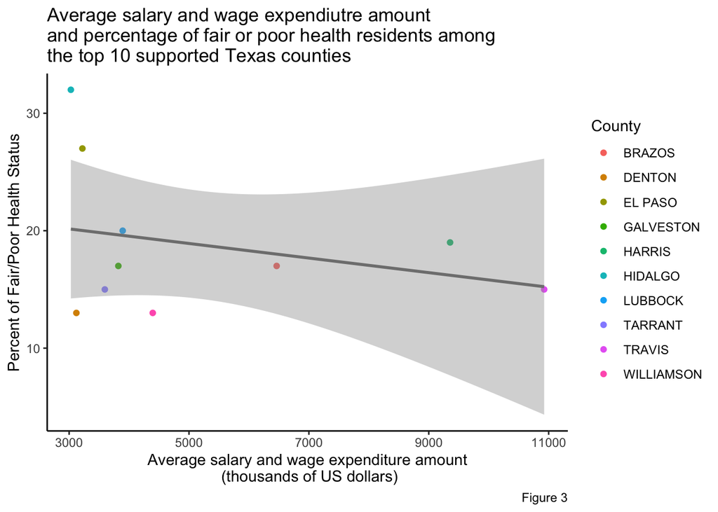

```r
topWages <-
  joinedHealthAndSal %>%
  top_n(Avg_Sal_Wages, n = 10)

ggplot(topWages, aes(x = Avg_Sal_Wages, y = `% Fair/Poor`, col = County)) +
  geom_point() +
  labs(x = 'Average salary and wage expenditure amount\n (thousands of US dollars)',
       y = 'Percent of Fair/Poor Health Status',
       title = 'Average salary and wage expendiutre amount \nand percentage of fair or poor health residents among \nthe top 10 supported Texas counties',
       caption = "Figure 3") +
  theme(plot.title = element_text(hjust = 0.5)) +
  geom_smooth(col = 'grey50',
              method = 'lm',
              alpha = 0.4) +
  theme_classic()
```

As demonstrated in the scatter plot, the regression line generated does exhibit a negative slope, supporting our initial beliefs. However, the degree to which the average salary and wage allotment predicts percent of fair/poor health residents would have to be further analyzed statistically. However some important aspects to note are that the average salary and wage amount for this group ranges from $3,000,000 to $11,000,000 (since the x-axis is in units of $1000). Furthermore, the percentage of each county’s fair or poor status also ranges between 10% and approximately 30%.

To further this exploration, all of the counties in Texas were explored in order to determine if a similar trend was apparent on a statewide scale.

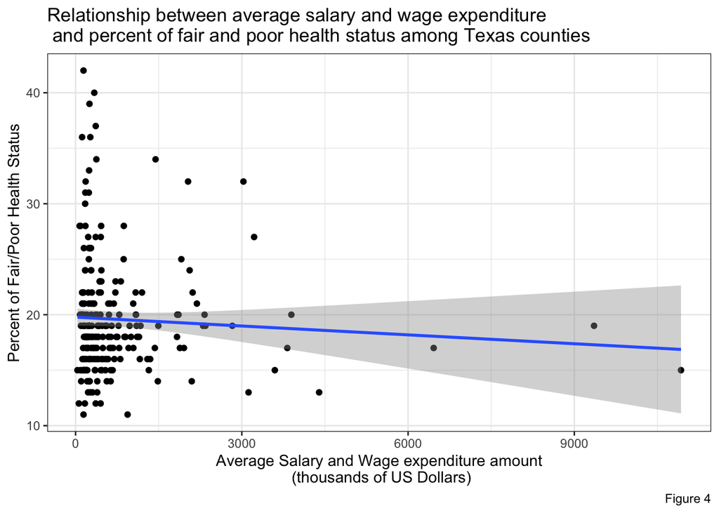

```r
joinedHealthAndSal <-
  joinedHealthAndSal %>%
  arrange(-`Avg_Sal_Wages`)

ggplot(joinedHealthAndSal, aes(x = Avg_Sal_Wages, y = `% Fair/Poor`)) +
  geom_point() +
  geom_smooth(method = 'lm') +
  labs(x = 'Average Salary and Wage expenditure amount\n (thousands of US Dollars)',
       y = 'Percent of Fair/Poor Health Status',
       title = 'Relationship between average salary and wage expenditure\n and percent of fair and poor health status among Texas counties',
       caption = 'Figure 4') +
  theme(plot.title = element_text(hjust = 0.5),
        legend.position = 'none') +
  theme_bw()
```

A scatter plot similar to the first one was created, however this plot did not take into account each county’s identity. While there are a few outliers that would meet this criteria, the overall trend does not strongly indicate this relationship. A slight negative slope is apparent, though not as apparent as the one observed for the smaller sample size of counties. Instead, the regression line indicates a weak correlation between the two variables.

In comparison to the first plot, where the sample size was much smaller, there is a high density of points in the $0 to $3,000,000 expenditure amount, where the percent of fair or poor health status varies widely among the counties. The percentage of fair or poor health status also has a greater range in comparison to the first plot, where this plot includes percentage values from 10% to over 40%. Furthermore, not many observations are visible past the $6,000,000 mark. This skew could ultimately have the implication of affecting the regression line generated.

### RQ 3: Total Spending and Total Violations

We will be exploring the relationship between the expenditures made by each county in the dataset `TX_Exp` and the violations that occurred in the dataset `TX_Envm_Violation`.

It is important to first notice that `TX_Exp` and `TX_Envm` both contain information from several different years. For our investigation, we are interested in information during 2017. While we can filter this straight away with `TX_Exp`, we found that our `TX_Envm` dataset displays the dates in `mm/dd/yyyy` format. Thus, we separated the column into `year`, `month`, and `day` columns to allow us to filter out the years.

```r
TX_2017_Exp <- TX_Exp %>%
  filter(`Fiscal Year` ==2017) # Look at only 2017 data

TX_2017_Envm <- TX_Envm %>%
  ## Tidying: Separating the column into 3 other columns ###
  separate(`Notice of Violation Date`, # We separate the date into 3 columns
           into = c("Month", "Day", "Year"),  # ...month, day, and year
           sep = "/",
           convert = T) %>%
  filter(Year == 2017) # ...then we filter 2017 data
```

Now, we want to calculate totals for both of the datasets before joining the two. We begin with calculating the total amount of expenditures performed by each county. Notice that our first county row is NA. A closer look at this row shows that this row looks at the totals of the entirety of Texas. Thus, for our data analysis, we would exclude this from our calculations.

```r
TX_2017_TotalExp <- TX_2017_Exp %>%
  filter(!is.na(County)) %>% # Filter out the "Texas Total" row
  select(County, `Major Spending Category`, Amount) %>% # look at counties and amounts
  group_by(County) %>% # for each county...
  summarize(Total_Exp_HTh = sum(Amount)/100000, # ... Find the total expenditure
            Avg_Exp_HTh = mean(Amount)/100000) # .. Find the average expenditure
```

With this summarization, we can take a look at how spread out the expenditure amounts are among the counties:

```r
summary(TX_2017_TotalExp$Total_Exp_HTh)
```

```
##     Min.  1st Qu.   Median     Mean  3rd Qu.     Max.     NA's
##     1.87   104.49   248.75   667.87   564.70 32537.15       87
```

- The smallest total expenditure a county did in 2017 was roughly $1.87 hundreds of thousands of dollars ($187,000), while the highest total expenditure was $32537.15 hundreds of thousands of dollars ($3,253,715,000).
- The average amount of total spending performed by a county is around $668 hundreds of thousands of dollars ($66,787,000).
- 87 Counties are missing totals

Next, we do the same total calculations for our Texas Environment dataset.

```r
TX_2017_TotalEnvm <- TX_2017_Envm %>%
  group_by(County) %>% # For each county...
  summarize("Total_Violations" = n()) # Count the # of violation
```

With totals calculated for each of our counties based on each dataset, we can now join the two datasets and graph the total expenditures against the total number of violations.

When joining, we notice that:

- There are 250 observations in `TX_2017_TotalEnvm` and 254 observations in `TX_2017_TotalExp`.
- The main ID variable used to join the two summary datasets is `County`.
- The variables not shared by both datasets include the calculated `Total_Violations`, `Total_Exp_Hth`, and `Avg_Exp_Hth`.
- For now, other variables originally present in our datasets, such as `Media` from `TX_Envm` and `Major Spending Category` from `TX_Exp` do not appear in our join.

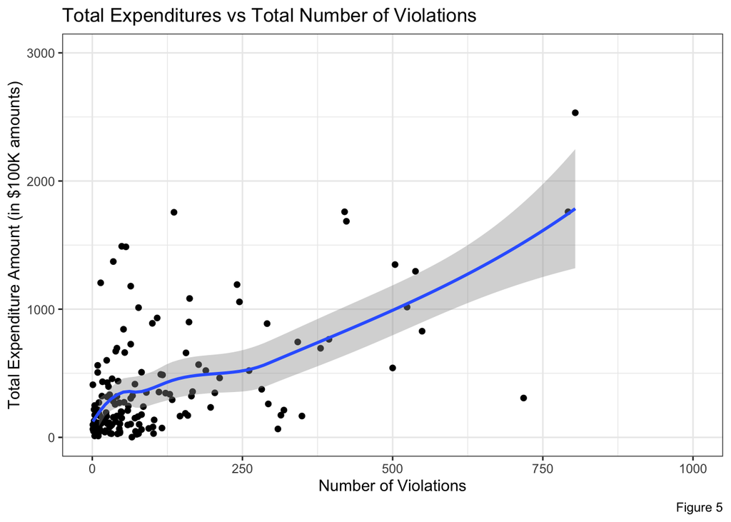

```r
left_join(TX_2017_TotalEnvm, TX_2017_TotalExp, by = "County") %>%

  ggplot(aes(x = Total_Violations, y = Total_Exp_HTh)) +
  geom_point() + # Point to identify each county
  geom_smooth() + # Line of best fit for our data
  xlim(0,1000) + # Limits of the graph
  ylim(0,3000) +
  labs(
    title = "Total Expenditures vs Total Number of Violations",
    x = "Number of Violations",
    y = "Total Expenditure Amount (in $100K amounts)",
    caption = "Figure 5"
  ) +
  theme_bw()
```

The resulting graph shows the total number of violations against the total expenditure amount of each county, with expenditure amounts being in $100k amounts. With the addition of a best fit line, there does appear to be a positive trend between violation totals and expenditure totals. However, a major cluster of data is centered around low expenditure and low violation amounts. In addition to this cluster, certain counties ranked extremely high in total expenditure amounts despite having a low number of violations. It might be that the use of $100k amounts rather than $1 amounts influences the data to appear to have a positive correlation. While the line does suggest a positive trend, the scale of our y-axis emphasizes that a large amount of money would be needed to show any correlation between violation amounts.

Comparing the total violations and total expenditures on their own produces interesting results, but perhaps inclusion of the type of violation could demonstrate further relationships. We thus introduce the `Media` variable into our analysis.

```r
# Take a look at total violations for each county-media pair
TX_2017_MediaEnvm <- TX_2017_Envm %>%
  group_by(County, Media) %>%
  summarize(Total_Violations = n())
```

Before merging the two datasets, it would be valuable to learn more about the `Media` variable. We explore this variable using a table and a visualization.

```r
table(TX_2017_Envm$Media) # Frequency Counts
```

```
##
##    AIR  WASTE  WATER
##  13902   5864 184554
```

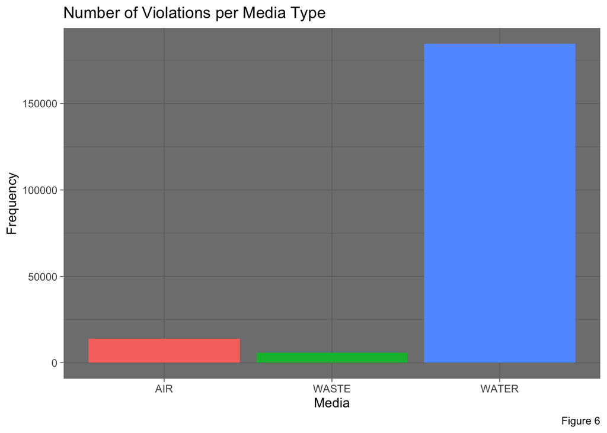

```r
TX_2017_Envm %>%
  group_by(Media) %>%
  summarize(Total = n()) %>% # getting the frequency of each media

  ggplot(aes(x = Media, y = Total, fill = Media)) + # bar graph of frequencies
  geom_bar(stat = "Identity") + # stat function to utilize calculated Totals
  labs(
    title = "Number of Violations per Media Type",
    x = "Media",
    y = "Frequency",
    caption = "Figure 6"
    ) +
  theme_dark() +
  theme(legend.position = "none")
```

We find that the most frequent type of environmental violation is Water with 184,554 violation notices. The other two categories, air and water, total at only 13,902 and 5,864 notices respectively, showing that Water Violations is the prevalent violation that occured in the counties of 2017.

Taking our previously constructed graph of Total Expenditures vs Total Violation, we can now include information on the Category of each violation. Prior to joining:

- There are 638 observations in `TX_2017_MediaEnvm` and 254 observations in `TX_2017_TotalExp`.
- The main ID variable used to join the two summary datasets is `County`.
- The variables not shared by both datasets include the calculated `Total_Violations`, `Total_Exp_Hth`, and `Avg_Exp_Hth`, as well as the `Media` variable.

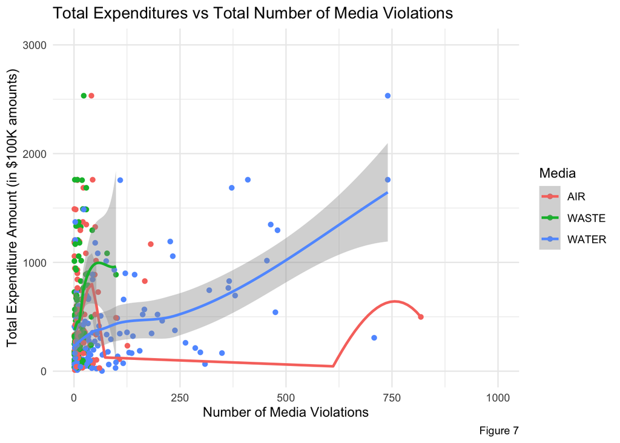

```r
left_join(TX_2017_MediaEnvm, TX_2017_TotalExp, by = "County") %>%

  ggplot(aes(x = Total_Violations, y = Total_Exp_HTh, color = Media)) + ## creating graph
  geom_point() + # Points to mark county-media pairs
  geom_smooth() + # Best-Fit Lines
  xlim(0,1000) + # Limits of our graph
  ylim(0, 3000) +
  labs(
    title = "Total Expenditures vs Total Number of Media Violations",
    x = "Number of Media Violations",
    y = "Total Expenditure Amount (in $100K amounts)",
    caption = "Figure 7"
  ) +
  theme_minimal()
```

The resulting graph shows the total number of violations against the total expenditure amount of each county, with expenditure amounts being in $100k amounts. Additionally, each point is given a color, identifying the type of Media associated with that violation. The graph shows that while Waste and Air violations alone do not demonstrate an immediate trend, Water appears to have the strongest positive correlations from the three medias. However, this might be solely due to the prevalence in Water violations at the time. As with the previous graph, perhaps the usage of $100K amounts might be influencing whether we see a correlation or not.

## 3. Discussion

Through the methods in this study, three research questions were answered…

**Research Question 1:** What is the relationship between the amount of air violations in a given county and the average daily “$pm_{2.5}$”?

- Figure 1 displays the range of average daily “$pm_{2.5}$” for all counties in Texas, establishing that all counties in Texas have average daily “$pm_{2.5}$” emissions that are below the regulation as set by the Environmental Protection Agency (EPA) of $12 µg/m^3$. In the same vein, Figure 2 provide a clear picture as to the relationship between the total amount of air violations and air pollution. Through visualization of the trend line, as seen it figure 2, there is a positive correlation between the total amount of air violations and average daily “$pm_{2.5}$”.

**Research Question 3:** What is the relationship between the expenditures made by each county in Texas and their respective violations?

- Figure 5 displays the number of violations against the total amount of expenditure made by each county. Each county was represented with a point and a line of best fit was added into the data. Certain outliers were removed from the finishing plot in order to focus on the cluster of data. From the cluster, we found that there does seem to be a positive correlation between Expenditure Totals and Violation Totals. However, it is important to emphasize that the scale of expenditures was in Hundreds of Thousands of Dollars, meaning that such a correlation is actually weaker than what is depicted.
- Figure 7 does a similar depiction as Figure 5 with the addition of the `media` variable. With this, 3 more lines were constructed, demonstrating if looking at specific types of violations demonstrated a better correlation. While Air and Waste-related violations did not show a significant correlation, Water Violations seemed to show a positive relationship between number of Violations and the total expenditure made by a county. The same issues as figure 5 follow, mainly being the scale used to construct the plot.
- Figure 6 simply shows how many types of violations were classified as being labeled as either a Water, Air, or Waste related violation. The resulting bar graph showed that Water violations were overwhelmingly higher compared to the other types of media. This might explain why water-related environmental violations had a better correlation between number of violations and expenditure totals in Figure 7.

### Reflection

The process of constructing this project was time-intensive and laborious. The project itself is the amalgamation of late nights, long hours, and multiple corrections divided amongst the three group mates. However, the process itself was enjoyable and an opportunity to grow stronger in the development of a new coding language. The process of constructing the end-product presented many new complications, that were not directly addressed in class. Therefore, it took ingenuity and creativity to format and solve through certain aspects of the project. Moreover, it took communication skills to work on a project that did not allow for corrections/editing to be made simultaneously. To combat this issue, we saved and distributed a .rmd file many times, with each person editing their portion of the work as time went on. This arduous process eventually led to one final draft in a .rmd file. All in all, the process of creating this work was difficult and presented many issues. However, it was an opportunity for each of us to grow stronger in R and our interpersonal skills.

### Acknowledgements

**Erick Garcia:**

- Responsible for the creation, formatting, and response to research question 3. He aided in the development of the format of the project by creating the first preliminary .rmd file (outline). Began document processing, through the importation of .csv files and cleaning the messy `TX_Health` dataset, from excel.

**Gerardo Gonzalez:**

- Responsible for the creation, formatting, and response to research question 1. He aided in the final format of the project by merging all work into one .rmd file. Is primarily responsible, for the format and responses in the conclusion (discussion, reflection, and acknowledgments).

**Nicholas Calzada:**

- Responsible for the creation, formatting, and response to research question 2. He is primarily responsible, for the format and responses in the introduction (Narrative Introduction, Citing sources, unique factors of data).